## Ex-02.2-ghq

Paul Johnson, CRMDA <pauljohn@ku.edu>

Feb. 8 2018

Abstract

RHS anorexia exercise

# Data import

```r
if (!file.exists("ghq.csv")){
    ghq <- data.frame(
        id = seq(1, 12, by =1),
        g = c(12, 8, 22, 10, 10, 6, 8, 4, 14, 6, 2, 22, 12, 7, 24, 14, 8, 4, 5, 6, 14, 5, 5, 16),
        occasion = rep(c(1,2), each = 12)
    )
    write.csv(ghq, "ghq.csv", row.names = FALSE)
} else {
    ghq <- read.csv("ghq.csv")
}
```

```r
rockchalk::summarize(ghq)
```

```
## Numeric variables
##              id      g     occasion
## min         1       2       1
## med         6.50    8       1.50
## max        12      24       2
## mean        6.50   10.17    1.50
## sd          3.53    6.10    0.51
## skewness    0       0.85    0
## kurtosis   -1.36   -0.34   -2.08
## nobs       24      24      24
## nmissing    0       0       0
```

```r
ghq$id.orig <- ghq$id
ghq$id <- as.factor(ghq$id)
```

# 2.2.1: No Reshape Required

We created the ghq data in the long format, so no reshaping is needed.

```r
ghq
```

```
##    id  g occasion id.orig
## 1   1 12        1       1
## 2   2  8        1       2
## 3   3 22        1       3
## 4   4 10        1       4
## 5   5 10        1       5
## 6   6  6        1       6
## 7   7  8        1       7
## 8   8  4        1       8
## 9   9 14        1       9
## 10 10  6        1      10
## 11 11  2        1      11
## 12 12 22        1      12
## 13  1 12        2       1
## 14  2  7        2       2
## 15  3 24        2       3
## 16  4 14        2       4
## 17  5  8        2       5
## 18  6  4        2       6
## 19  7  5        2       7
## 20  8  6        2       8
## 21  9 14        2       9
## 22 10  5        2      10
## 23 11  5        2      11
## 24 12 16        2      12
```

# 2.2.1b: mixed model with REML

```r
library(lme4)
m1 <- lmer(g ~ (1|id), data = ghq, REML = TRUE)
summary(m1)
```

```
## Linear mixed model fit by REML ['lmerMod']
## Formula: g ~ (1 | id)
##    Data: ghq
##
## REML criterion at convergence: 131.3
##
## Scaled residuals:
##      Min       1Q   Median       3Q      Max
## -1.33737 -0.57848  0.07356  0.41406  1.79603
##
## Random effects:
##  Groups   Name        Variance Std.Dev.
##  id       (Intercept) 35.045   5.920
##  Residual              3.667   1.915
## Number of obs: 24, groups:  id, 12
##
## Fixed effects:
##             Estimate Std. Error t value
## (Intercept)   10.167      1.753   5.799
```

```r
confint(m1, method = "profile")
```

```
## Computing profile confidence intervals ...
```

```
##                2.5 %    97.5 %
## .sig01      3.837756  9.123181
## .sigma      1.345166  3.037310
## (Intercept) 6.595290 13.738043
```

# 2.2.1c: predictions of random effects

## Retrieve predictions of the random effects from m1.

```r
m1.ranef <- ranef(m1, condVar = TRUE)
m1.ranef
```

```
## $id
##    (Intercept)
## 1     1.742194
## 2    -2.534100
## 3    12.195357
## 4     1.742194
## 5    -1.108669
## 6    -4.909819
## 7    -3.484388
## 8    -4.909819
## 9     3.642769
## 10   -4.434675
## 11   -6.335251
## 12    8.394207
##
## with conditional variances for "id"
```

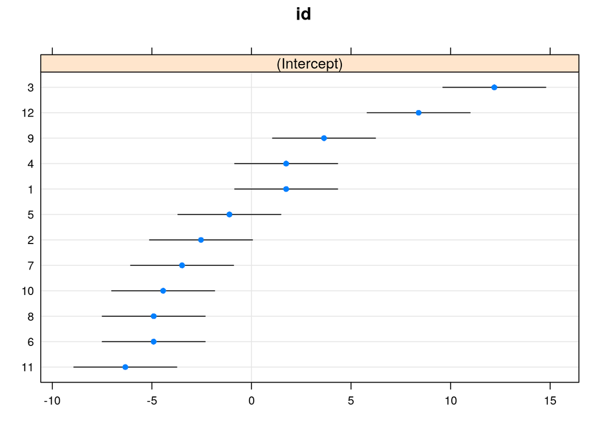

```r
library(lattice)
dotplot(m1.ranef)
```

This is a way of “extracting” the vector of posterior modes of the group deviations about the overall center point.

```r
m1.ranef.byid <- m1.ranef[["id"]][ , "(Intercept)"]
m1.ranef.byid
```

```
##  [1]  1.742194 -2.534100 12.195357  1.742194 -1.108669 -4.909819 -3.484388
##  [8] -4.909819  3.642769 -4.434675 -6.335251  8.394207
```

The vector `m1.ranef.byid` is generated by lme4 using penalized least squares estimation. This means that it is not, actually, calculated by the formula we find in the textbooks for posterior modes of random effects. However, the usual formula can be used to produce the same thing, in (almost all) cases I’ve tried.

Here is the “usual formula”, with words in place of some symbols:

$$EmpBayes~Ranef = \lambda_j group~average_j + (1-\lambda_j) overall~average$$

This formula is simple. The term I call `overall average` is the mean of observed scores. It is the intercept we get when we run a regression with no predictors. It is same as we would get taking an average of all scores, of course.

```r
lm0 <- lm(g ~ 1, data = ghq)
overallavg <- unname(coef(lm0)[1])
overallavg
```

```
## [1] 10.16667
```

On the other hand, the average within each group is the “fixed effects” estimate obtained by a linear model that does not include an intercept.

```r
lm1 <- lm(g ~ 0 + id, data = ghq)
groupavg <- coef(lm1)
groupavg
```

```
##  id1  id2  id3  id4  id5  id6  id7  id8  id9 id10 id11 id12
## 12.0  7.5 23.0 12.0  9.0  5.0  6.5  5.0 14.0  5.5  3.5 19.0
```

In R, we can get the same result by using the `by` or `aggregate` functions, like so

```r
aggregate(ghq$g, list(id = ghq$id), mean, na.rm = TRUE)
```

```
##    id    x
## 1   1 12.0
## 2   2  7.5
## 3   3 23.0
## 4   4 12.0
## 5   5  9.0
## 6   6  5.0
## 7   7  6.5
## 8   8  5.0
## 9   9 14.0
## 10 10  5.5
## 11 11  3.5
## 12 12 19.0
```

To reproduce the “empirical bayes” statements about group averages, we now need to calculate $\lambda_j$. The formula depends on the estimated variances of $\varepsilon$ (individual row level random effect) the variance of the group-level intercept.

$$\lambda_j = \frac{var~of~random~effect}{var~of~random~effect +
\frac{var~of~residual}{n~of~cases~group~j}}$$

Because both of our groups in this case have 2 observations for each of 12 groups, this is very easy to calculate. The $\lambda_j$ is actually the same for all groups. If you allow me to simply read the output from the regression output above, I’ll take the standard deviations of the random effect and square them, as:

```r
lambda <- 5.92^2 / (5.92^2 + (1.915^2)/rep(2, 12))
lambda
```

```
##  [1] 0.9502817 0.9502817 0.9502817 0.9502817 0.9502817 0.9502817 0.9502817
##  [8] 0.9502817 0.9502817 0.9502817 0.9502817 0.9502817
```

```r
eb.blups <- lambda * groupavg + (1 - lambda) * overallavg
eb.blups
```

```
##       id1       id2       id3       id4       id5       id6       id7
## 11.908850  7.632582 22.361948 11.908850  9.058005  5.256878  6.682301
##       id8       id9      id10      id11      id12
##  5.256878 13.809413  5.732019  3.831456 18.560821
```

Note that the empirical Bayes statements about the group averages are the same values returned by the `coef` function in `lme4`:

```r
coef(m1)
```

```
## $id
##    (Intercept)
## 1    11.908861
## 2     7.632566
## 3    22.362024
## 4    11.908861
## 5     9.057998
## 6     5.256847
## 7     6.682279
## 8     5.256847
## 9    13.809436
## 10    5.731991
## 11    3.831416
## 12   18.560874
##
## attr(,"class")
## [1] "coef.mer"
```

A student wonders why are these not the same as the values reported by `ranef(m1)` from `lme4`, and the answer is that the random effects are variations that fluctuate around the overall average. Hence, the predictions of the group averages are equal to the random effects the average, as we see here:

```r
overallavg + m1.ranef.byid
```

```
##  [1] 11.908861  7.632566 22.362024 11.908861  9.057998  5.256847  6.682279
##  [8]  5.256847 13.809436  5.731991  3.831416 18.560874
```

When I did those calculations, I gave myself an easy approach by reading the estimates 5.92 and 1.915 from the model output and typing those in. It turns out it is not too easy to extract those values from the `lme4` fitted model, but here is how it can be done.

The estimated standard deviation of the residual error term, which should be 1.915 in the output (rounded).

```r
m1.resid.sd <- attr(VarCorr(m1), "sc")
m1.resid.sd
```

```
## [1] 1.914854
```

```r
## Again, not easy. That is tucked away as an attribute of VarCorr output
```

The the estimated standard deviation of the random effect, the group intercept term, is 5.92 in the output and we can extract it from the model:

```r
m1.id.sd <- attr(VarCorr(m1)[["id"]], "stddev")
m1.id.sd
```

```
## (Intercept)
##     5.91992
```

And the number within each group can be retrieved as

```r
npergroup <- aggregate(ghq$id, list(id = ghq$id), length)
```

but since that is 2 for each group, it hardly seems worth the effort.

```r
## shrinkage <- psi_hat/(psi_hat + (theta_hat/12))
lambda2 <- m1.id.sd^2 / (m1.id.sd^2 + (m1.resid.sd^2 / npergroup$x))
lambda2
```

```
##  [1] 0.9502876 0.9502876 0.9502876 0.9502876 0.9502876 0.9502876 0.9502876
##  [8] 0.9502876 0.9502876 0.9502876 0.9502876 0.9502876
```

The values in `lambda2` are more accurate because I did not type in the values, I retrieved them in full numerical precision from the model. But they are, practically speaking, equivalent. See?

```r
lambda
```

```
##  [1] 0.9502817 0.9502817 0.9502817 0.9502817 0.9502817 0.9502817 0.9502817
##  [8] 0.9502817 0.9502817 0.9502817 0.9502817 0.9502817
```

The difference is trivial:

```r
lambda2 - lambda
```

```
##  [1] 5.919045e-06 5.919045e-06 5.919045e-06 5.919045e-06 5.919045e-06
##  [6] 5.919045e-06 5.919045e-06 5.919045e-06 5.919045e-06 5.919045e-06
## [11] 5.919045e-06 5.919045e-06
```

# 2.2.3 Allow occasion as a predictor

```r
m2 <- lmer(g ~ factor(occasion)  + (1|id), data = ghq)
summary(m2)
```

```
## Linear mixed model fit by REML ['lmerMod']
## Formula: g ~ factor(occasion) + (1 | id)
##    Data: ghq
##
## REML criterion at convergence: 129.8
##
## Scaled residuals:
##      Min       1Q   Median       3Q      Max
## -1.18982 -0.47816  0.03077  0.40354  1.66522
##
## Random effects:
##  Groups   Name        Variance Std.Dev.
##  id       (Intercept) 34.909   5.908
##  Residual              3.939   1.985
## Number of obs: 24, groups:  id, 12
##
## Fixed effects:
##                   Estimate Std. Error t value
## (Intercept)        10.3333     1.7993   5.743
## factor(occasion)2  -0.3333     0.8103  -0.411
##
## Correlation of Fixed Effects:
##             (Intr)
## fctr(ccsn)2 -0.225
```

The fact that the t-statistic for the occassion is not statistically significant (t = -0.41, p = 0.68) indicates that there is no “mean shift” between measurement occasions.